# Georgia Election Results Walkthrough

Author

Leandra Purvis

Published

November 11, 2022

# Introduction

The data used for this assignment includes Georgia election results by county for U.S. Senate and Governor in 2022, President in 2020, and then some of the same socioeconomic factors we’ve looked at other contexts so far during the semester.

```r
#import the GA election data for this assignment

#GA senate
senate_results <- read_excel(here("docs/ga_votes.xlsx"), sheet = "senate")

#GA governor
governor_results <- read_excel(here("docs/ga_votes.xlsx"), sheet = "governor")
```

# Charts

**1)**

The following chart demonstrates how many countries the Republican candidate did better vs. worse than Trump in the Senate race. I did this by first creating a count of the counties where the Republican cadidate did better than Trump using the “count” function of the column ‘is_r_above_trump’. I then used ggplot to graph this data. I used the function “aes” to tell r which variables represented what (x represented ‘yes’ or ‘no’ that the candidate did better than Trump, and y represented the amount of countiess). Further instructions were about design of the graph - “geom_col” allowed me to design the colors of the graph, “coord_flip” allowed me to change the orientation of the graph, and then I was able to name x and y using “name =”.

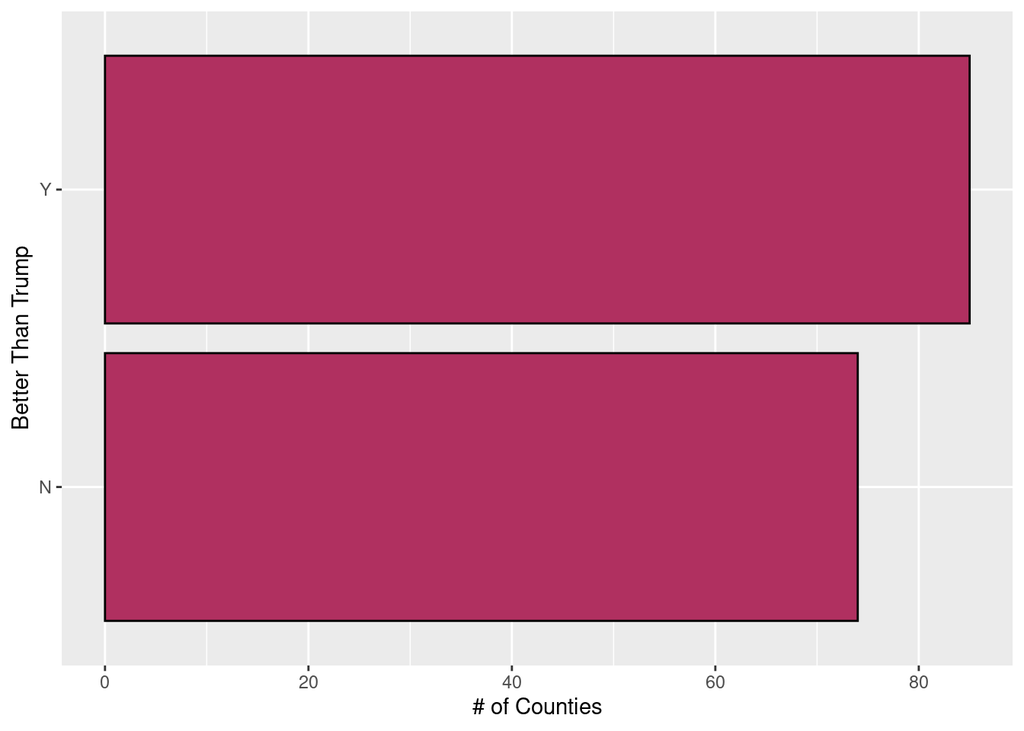

```r
county_count <- senate_results %>%
  count(is_r_above_trump)

ggplot(county_count, aes(x = is_r_above_trump , y = n ))+
  geom_col(color="black", fill="maroon")+
  coord_flip()+
  scale_y_continuous(name = "# of Counties")+
  scale_x_discrete(name = "Better Than Trump")
```

**2)**

I then repeated the same process using the same functions for the race for the governor.

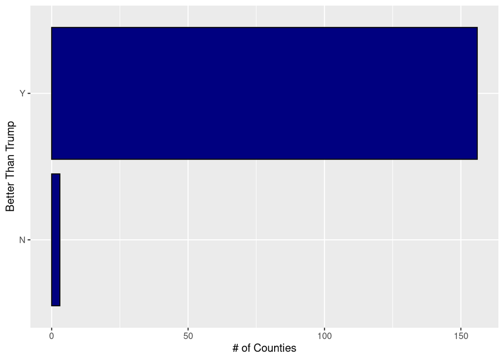

```r
gov_count <- governor_results %>%
  count(is_r_above_trump)
ggplot(gov_count, aes(x = is_r_above_trump , y = n ))+
  geom_col(color="black", fill="navy")+
  coord_flip()+
  scale_y_continuous(name = "# of Counties")+
  scale_x_discrete(name = "Better Than Trump")
```

**3)**

Next I wanted to create a chart that demonstrated the top ten biggest drops between the Republican candidate and Trump. In other words I wanted to show candidates with the highest percent drop from Trump.

```r
biggest_drops <- senate_results %>%
  filter(pct_r_above_trump<1) %>%
  arrange(pct_r_above_trump) %>%
  head(10)
biggest_drops
```

```
# A tibble: 10 × 27
   officeName  statePos…¹ fipsC…² county state…³ total…⁴ democ…⁵ repub…⁶ pct_d…⁷
   <chr>       <chr>      <chr>   <chr>  <chr>     <dbl>   <dbl>   <dbl>   <dbl>
 1 U.S. Senate GA         13151   Henry  GA        95117   60645   32817    63.8
 2 U.S. Senate GA         13247   Rockd… GA        34701   25421    8708    73.3
 3 U.S. Senate GA         13097   Dougl… GA        52666   34095   17573    64.7
 4 U.S. Senate GA         13223   Pauld… GA        66615   24336   40647    36.5
 5 U.S. Senate GA         13063   Clayt… GA        83836   73310    9437    87.4
 6 U.S. Senate GA         13217   Newton GA        42636   24309   17546    57
 7 U.S. Senate GA         13241   Rabun  GA         8206    1804    6179    22
 8 U.S. Senate GA         13053   Chatt… GA         1015     453     538    44.6
 9 U.S. Senate GA         13085   Dawson GA        13832    2257   11168    16.3
10 U.S. Senate GA         13113   Fayet… GA        59905   28250   30162    47.2
# … with 18 more variables: pct_r_2022 <dbl>, winner_2022 <chr>, flipped <chr>,
#   pct_r_above_trump <dbl>, is_r_above_trump <chr>, medincome <dbl>,
#   medage <dbl>, pct_race_nonwhite <dbl>, pct_ed_college_all <dbl>,
#   medincome_abovebelow_natl <chr>, medage_abovebelow_natl <chr>,
#   pct_race_nonwhite_abovebelow_natl <chr>,
#   pct_ed_college_all_abovebelow_natl <chr>, democrat_2020 <dbl>,
#   republican_2020 <dbl>, pct_d_2020 <dbl>, pct_r_2020 <dbl>, …
```

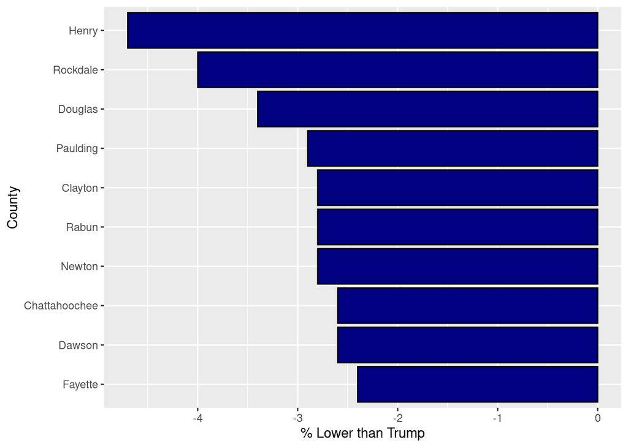

```r
ggplot(biggest_drops, aes(x = reorder(county,desc(pct_r_above_trump)) , y = pct_r_above_trump ))+
  geom_col(color="black", fill="navy")+
  coord_flip()+
  scale_y_continuous(name = "% Lower than Trump")+
  scale_x_discrete(name = "County")
```

**4)**

Next, for the Senate race, I created a chart that shows the top 10 counties with the highest margins of victory for the Democratic candidate. I began I using the senate_results and using the “group_by” function to show only the counties *(group_by(county))*. I then used the “summarise” function to calculate my margin by dividing the percent of Democrats who won over the percent of Republicans who won *(summarise(dem_margin_s = pct_d_2022/pct_r_2022))*. I then used the same “arrange” and “head” functions as before to sort my newly calculated values in descending order and to only show the top 10. I then created my graph in the same manner as done above.

```r
dem_win_s <- senate_results %>%
  group_by(county) %>%
  summarise(dem_margin_s = pct_d_2022/pct_r_2022) %>%
  arrange(desc(dem_margin_s)) %>%
  head(10)
dem_win_s
```

```
# A tibble: 10 × 2
   county    dem_margin_s
   <chr>            <dbl>
 1 Clayton           7.73
 2 DeKalb            5.98
 3 Fulton            2.99
 4 Rockdale          2.92
 5 Clarke            2.64
 6 Dougherty         2.39
 7 Hancock           2.39
 8 Richmond          2.23
 9 Douglas           1.94
10 Henry             1.85
```

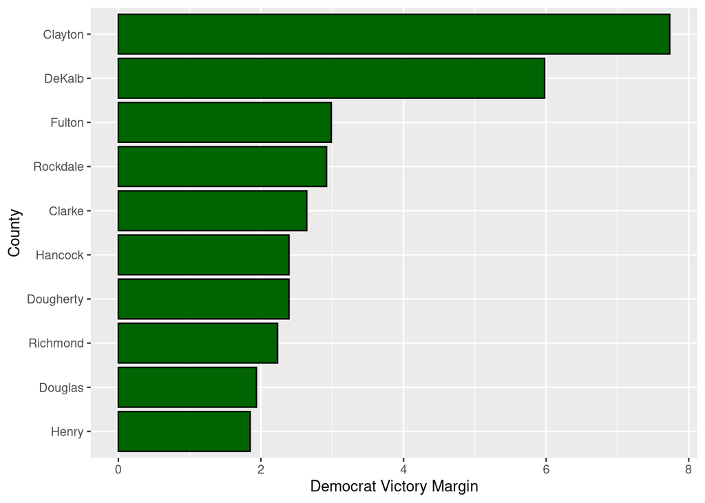

```r
ggplot(dem_win_s, aes(x = reorder(county,dem_margin_s) , y = dem_margin_s ))+
  geom_col(color="black", fill="dark green")+
  coord_flip()+
  scale_y_continuous(name = "Democrat Victory Margin")+
  scale_x_discrete(name = "County")
```

**5)**

The same process was then repeated from the governor’s race.

```r
dem_win_g <- governor_results %>%
  group_by(county) %>%
  summarise(dem_margin_g = pct_d_2022/pct_r_2022) %>%
  arrange(desc(dem_margin_g)) %>%
  head(10)
dem_win_g
```

```
# A tibble: 10 × 2
   county    dem_margin_g
   <chr>            <dbl>
 1 Clayton           6.43
 2 DeKalb            4.43
 3 Rockdale          2.49
 4 Fulton            2.26
 5 Hancock           2.15
 6 Dougherty         2.12
 7 Clarke            2.05
 8 Richmond          1.95
 9 Douglas           1.66
10 Henry             1.60
```

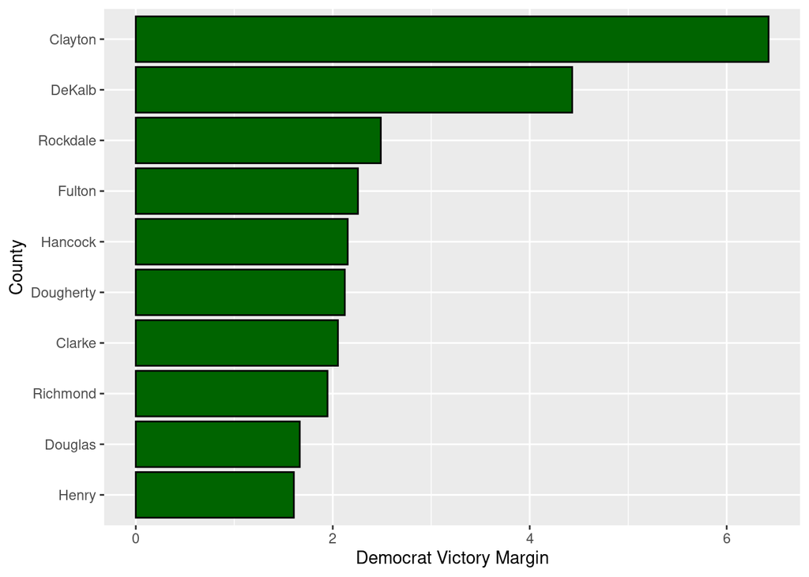

```r
ggplot(dem_win_g, aes(x = reorder(county,dem_margin_g) , y = dem_margin_g ))+
  geom_col(color="black", fill="dark green")+
  coord_flip()+
  scale_y_continuous(name = "Democrat Victory Margin")+
  scale_x_discrete(name = "County")
```

# Maps

*For this section use the `tmap` package to create your charts.*

To help start things out for you, we’re going to download a geospatial/map dataset with the county boundaries for Georgia. We’ll use the `tigris` package to do this.

```r
counties_geo <- tigris::counties(state = "GA", resolution = "20m", cb = TRUE)
```

Using the tmap package we are able to use the following functions to map out the stage of Georgia

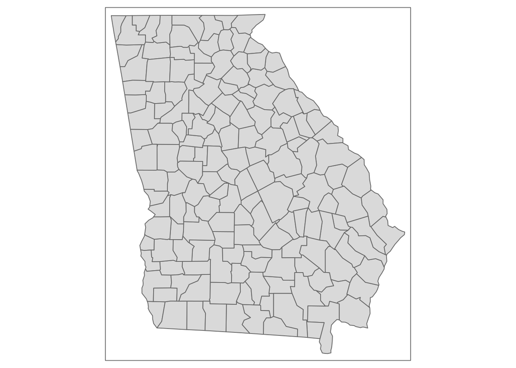

```r
tm_shape(counties_geo) +
  tm_polygons()
```

Great, it looks like we should be good to go. Use the newly created map data in `counties_geo` along with our election results datasets to complete the questions below.

**7)**

For the Senate race, create a choropleth (shaded) map of Georgia counties that shows where the Republican candidate for Senate did better vs. worse than Trump.

To create my choropleth map I began by first using the “inner_join” function to join the data between “counties_geo” and “senate_results”. This is necessary because the same data is labeled under different names in each set. So, now, R knows that “GEOID” and “fipsCode” are the same things and can be correlated when making the map. “glimpse” then allows us to view the newly joined map.

Next, “tmap_mode” with the mode=“plot” , it will add a structure to our map for the shading. Then finally, we will use *(tm_shape(districtmap_s) + tm_polygons(“pct_r_above_trump”, id = “county”)* which will map the counties where the senate candidate did better than Trump and the shading shows by how much.

```r
districtmap_s <- inner_join(counties_geo, senate_results, by = c("GEOID" = "fipsCode"))
glimpse(districtmap_s)
```

```
Rows: 159
Columns: 39
$ STATEFP                            <chr> "13", "13", "13", "13", "13", "13",…
$ COUNTYFP                           <chr> "239", "287", "067", "263", "177", …
$ COUNTYNS                           <chr> "00350547", "00343238", "01686112",…
$ AFFGEOID                           <chr> "0500000US13239", "0500000US13287",…
$ GEOID                              <chr> "13239", "13287", "13067", "13263",…
$ NAME                               <chr> "Quitman", "Turner", "Cobb", "Talbo…
$ NAMELSAD                           <chr> "Quitman County", "Turner County", …
$ STUSPS                             <chr> "GA", "GA", "GA", "GA", "GA", "GA",…
$ STATE_NAME                         <chr> "Georgia", "Georgia", "Georgia", "G…
$ LSAD                               <chr> "06", "06", "06", "06", "06", "06",…
$ ALAND                              <dbl> 391703076, 739227758, 880018853, 10…
$ AWATER                             <dbl> 24158295, 11818093, 12407739, 87668…
$ officeName                         <chr> "U.S. Senate", "U.S. Senate", "U.S.…
```

[output cut: 26 more lines]

```r
tmap_mode(mode = "plot")
```

```
tmap mode set to plotting
```

```
Variable(s) "pct_r_above_trump" contains positive and negative values, so midpoint is set to 0. Set midpoint = NA to show the full spectrum of the color palette.
```

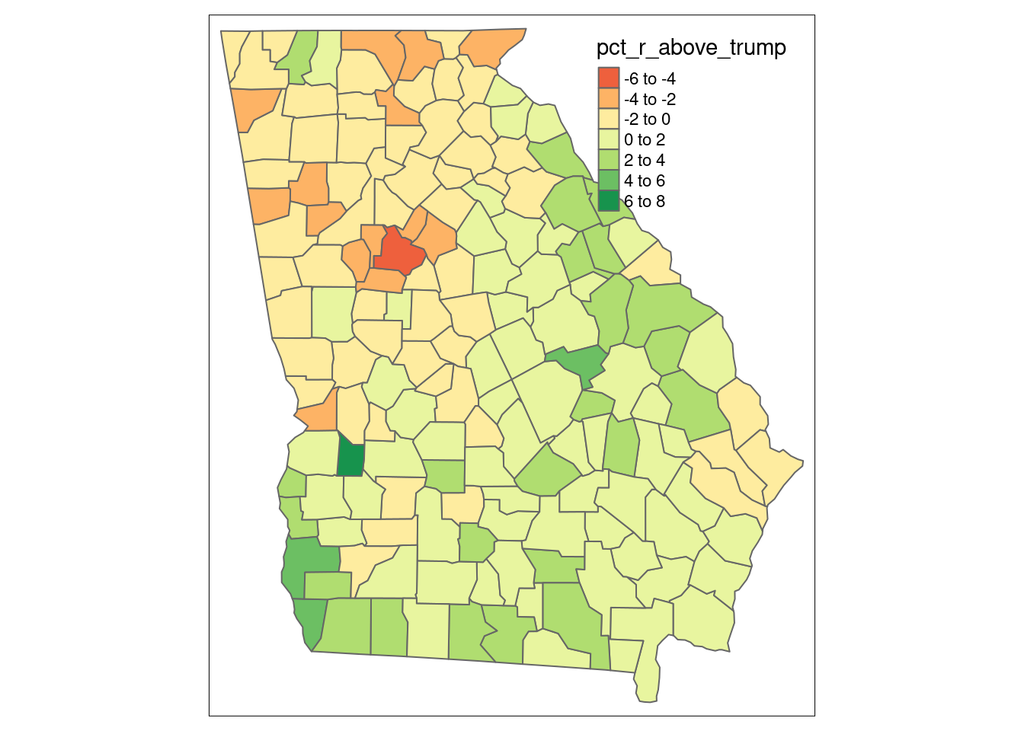

```r
tm_shape(districtmap_s) +
  tm_polygons("pct_r_above_trump", id = "county")
```

**8)**

The same process was then repeated for the governor’s race.

```r
districtmap_g <- inner_join(counties_geo, governor_results, by = c("GEOID" = "fipsCode"))
glimpse(districtmap_g)
```

```
Rows: 159
Columns: 39
$ STATEFP                            <chr> "13", "13", "13", "13", "13", "13",…
$ COUNTYFP                           <chr> "239", "287", "067", "263", "177", …
$ COUNTYNS                           <chr> "00350547", "00343238", "01686112",…
$ AFFGEOID                           <chr> "0500000US13239", "0500000US13287",…
$ GEOID                              <chr> "13239", "13287", "13067", "13263",…
$ NAME                               <chr> "Quitman", "Turner", "Cobb", "Talbo…
$ NAMELSAD                           <chr> "Quitman County", "Turner County", …
$ STUSPS                             <chr> "GA", "GA", "GA", "GA", "GA", "GA",…
$ STATE_NAME                         <chr> "Georgia", "Georgia", "Georgia", "G…
$ LSAD                               <chr> "06", "06", "06", "06", "06", "06",…
$ ALAND                              <dbl> 391703076, 739227758, 880018853, 10…
$ AWATER                             <dbl> 24158295, 11818093, 12407739, 87668…
$ officeName                         <chr> "Governor", "Governor", "Governor",…
```

[output cut: 26 more lines]

```r
tmap_mode(mode = "plot")
```

```
tmap mode set to plotting
```

```
Variable(s) "pct_r_above_trump" contains positive and negative values, so midpoint is set to 0. Set midpoint = NA to show the full spectrum of the color palette.
```

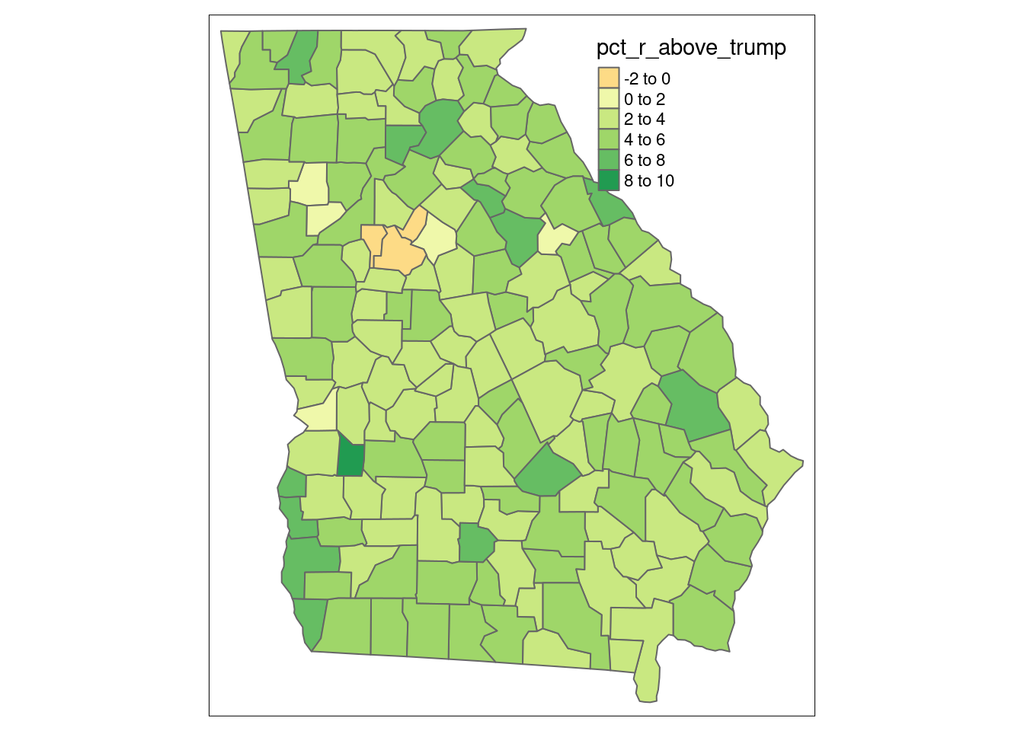

```r
tm_shape(districtmap_g) +
  tm_polygons("pct_r_above_trump", id = "county")
```

**9)**

For the Senate race, create a choropleth map that shows the margins of victory for the Democratic candidate. To do that you’ll need to compare the Democratic candidate’s percentage (pct_d_2022) with the Republican’s (pct_r_2022) to calculate the margin of victory for each county.

To calculate the margin of victory I used the “mutate” function to give us a new column for our calculated results and then subtracted the Democrats’ percentage by the Republicans’. I then repeated the same steps as above to create the map.

```
Variable(s) "dem_margin_s" contains positive and negative values, so midpoint is set to 0. Set midpoint = NA to show the full spectrum of the color palette.
```

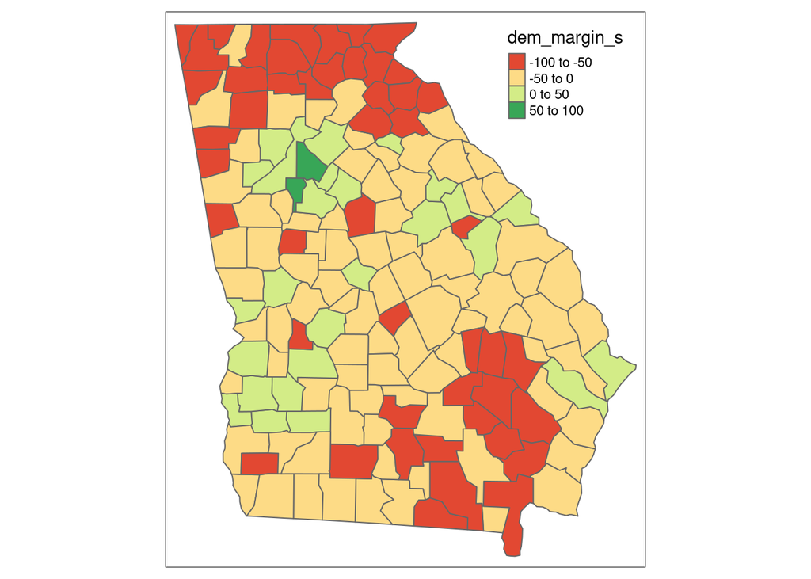

```r
districtmap_margin_s <- districtmap_s %>%
  mutate(dem_margin_s = pct_d_2022-pct_r_2022)

tm_shape(districtmap_margin_s) +
  tm_polygons("dem_margin_s", id = "county")
```

**10)**

The same process was followed as the previous step except this time for the governor’s race.

```
Variable(s) "dem_margin_g" contains positive and negative values, so midpoint is set to 0. Set midpoint = NA to show the full spectrum of the color palette.
```

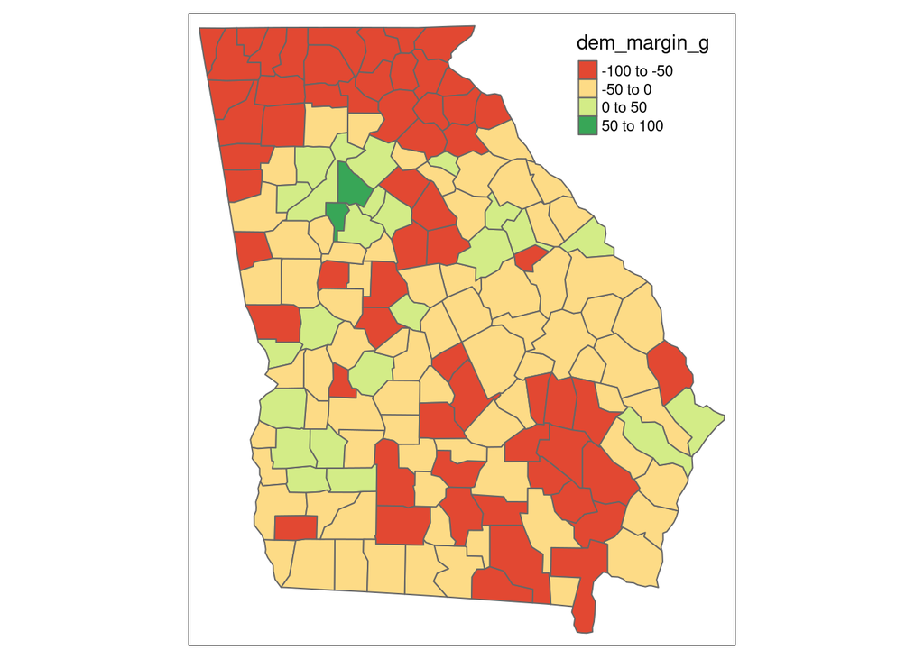

```r
districtmap_margin_g <- districtmap_g %>%
  mutate(dem_margin_g = pct_d_2022-pct_r_2022)

tm_shape(districtmap_margin_g) +
  tm_polygons("dem_margin_g", id = "county")
```